# Premium Discount Notebook

An exploration into the times series nature of premium and discounts for CEFs. The goal is to be able to make a prediction about the premium/discount (PD)

We’ll start with one CEF (Ticker AFB). Does a large discount or premium relative to a historical mean tend to revert toward the mean? For the mean we create a rolling 200 day moving average (SMA200). We also create a rolling 200 day standard deviation. The premium/discount (PD) is normalized in the variable PDZ. PD21L is the PD 21 days (approximately one month) into the future. PDZ21L is PD21L normalized using the current (same time as PDZ) SMA200 and SD200. So if SMA200, SD200, and PDZ are calculated on 6/1/XXXX, PD21L will be the PD about one calendar month in the future. PDZ21L is PD21L normalized using the average and standard deviation as of 6/1/XXXX. The reason for this is that as of the current date (e.g. 6/1/XXXX), we want to see how the PD moves using data as of the current date. The 200 and 21 days were chosen without much thought and we may want to investigate other values.

```r
sym <- "AFB"
pd <- cef_daily %>%
    filter(symbol == sym) %>%
    mutate(SMA200 = roll_meanr(prem, 200, fill=NA)) %>%
    mutate(SD200 = roll_sdr(prem, 200, fill=NA)) %>%
    mutate(PDZ = (prem - SMA200)/SD200) %>%
    mutate(PD21L = lead(prem, 21, fill=NA)) %>%
    mutate(PDZ21L = (PD21L - SMA200)/SD200) %>%
    mutate(PDChg = PD21L - prem) %>%
    mutate(Ret21L = roll_prodl(return.mkt+1, n=21, fill=NA)/roll_prodl(return.mkt+1, n=1, fill=NA)-1) %>%
    select(symbol, date, prem, SMA200, SD200, PD21L, PDZ, PDZ21L, PDChg) %>%
    na.omit
```

The following chart shows the premium / discount over time along with the SMA200 and dotted lines one standard deviation around the average.

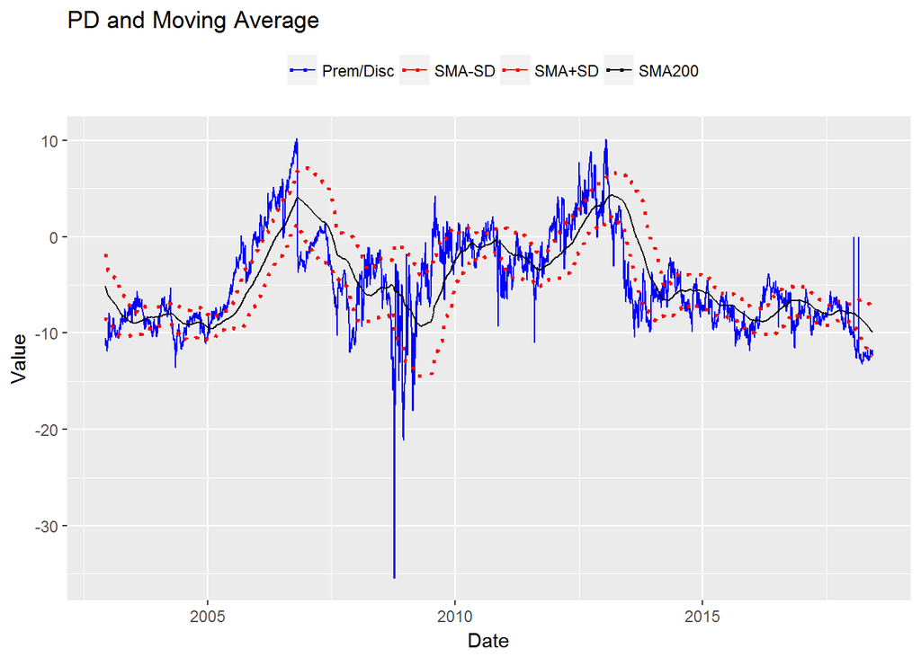

```r
ggplot(data = pd, aes(x=date, y=prem)) + geom_line(aes(color="Prem/Disc")) +
    geom_line(aes(y=SMA200, color="SMA200")) +
    geom_line(aes(y=SMA200+SD200, color="SMA+SD"), size=1, linetype="dotted") +
    geom_line(aes(y=SMA200-SD200, color="SMA-SD"), size=1, linetype="dotted") +
    ggtitle("PD and Moving Average") + xlab("Date") + ylab("Value") +
    scale_color_manual(name="", values = c("Prem/Disc" = "blue", "SMA200" = "black", "SMA+SD" = "red", "SMA-SD" = "red")) +
    theme(legend.position = "top")
```

Let’s look at the PD one month after the value is one standard deviation below (discount) or above (premium) the SMA200. Specifically we want to see how the PDZ changes. Note: these are not premiums/discounts in the absolute sense, but relative to the SMA200.

When discounts <= -1sd

```r
disc <- pd %>%
    filter(PDZ <= -1) %>%
    select(symbol, PDZ, PDZ21L, PDChg) %>%
    mutate(ZDiff = PDZ21L - PDZ) %>%
    mutate(ZRatio = PDZ21L/PDZ)
summary(disc)
```

```
    symbol               PDZ             PDZ21L             PDChg
 Length:916         Min.   :-6.516   Min.   :-11.4440   Min.   :-27.0330
 Class :character   1st Qu.:-1.996   1st Qu.: -2.0265   1st Qu.: -0.2877
 Mode  :character   Median :-1.603   Median : -1.2075   Median :  0.8660
                    Mean   :-1.722   Mean   : -1.2914   Mean   :  1.0646
                    3rd Qu.:-1.268   3rd Qu.: -0.5486   3rd Qu.:  1.9928
                    Max.   :-1.002   Max.   :  8.3430   Max.   : 29.8519
     ZDiff              ZRatio
 Min.   :-10.1625   Min.   :-4.9375
 1st Qu.: -0.1200   1st Qu.: 0.3667
 Median :  0.3749   Median : 0.7736
 Mean   :  0.4310   Mean   : 0.7640
 3rd Qu.:  1.0153   3rd Qu.: 1.0790
 Max.   : 10.0327   Max.   : 8.9302
```

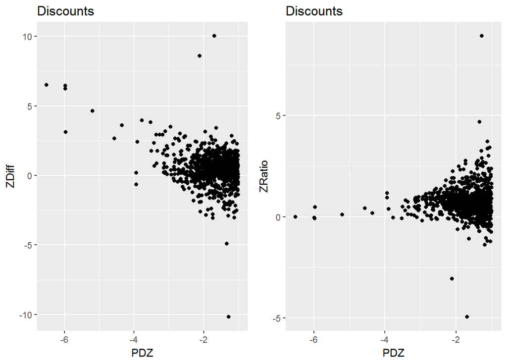

```r
p1 <- qplot(disc$PDZ, disc$ZDiff, main = "Discounts", xlab="PDZ", ylab="ZDiff")
p2 <- qplot(disc$PDZ, disc$ZRatio, main = "Discounts", xlab="PDZ", ylab="ZRatio")
grid.arrange(p1, p2, ncol=2)
```

When premiums >= 1sd

```r
prem <- pd %>%
    filter(PDZ >= 1) %>%
    select(symbol, PDZ, PDZ21L, PDChg) %>%
    mutate(ZDiff = PDZ21L - PDZ) %>%
    mutate(ZRatio = PDZ21L/PDZ)
summary(prem)
```

```
    symbol               PDZ            PDZ21L           PDChg
 Length:972         Min.   :1.001   Min.   :-3.104   Min.   :-13.2370
 Class :character   1st Qu.:1.250   1st Qu.: 0.803   1st Qu.: -1.5341
 Mode  :character   Median :1.563   Median : 1.475   Median : -0.2500
                    Mean   :1.662   Mean   : 1.435   Mean   : -0.5998
                    3rd Qu.:1.991   3rd Qu.: 2.227   3rd Qu.:  1.0929
                    Max.   :6.671   Max.   : 4.810   Max.   :  5.3505
     ZDiff             ZRatio
 Min.   :-9.3524   Min.   :-3.1016
 1st Qu.:-0.7194   1st Qu.: 0.5642
 Median :-0.1226   Median : 0.9232
 Mean   :-0.2271   Mean   : 0.8737
 3rd Qu.: 0.5380   3rd Qu.: 1.3339
 Max.   : 2.9554   Max.   : 3.6970
```

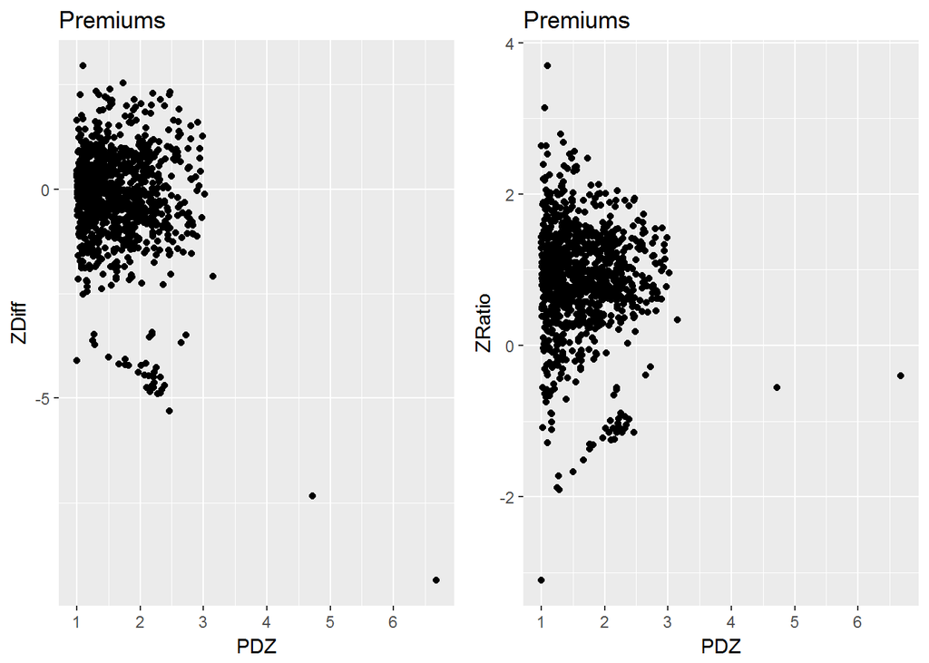

```r
p1 <- qplot(prem$PDZ, prem$ZDiff, main = "Premiums", xlab="PDZ", ylab="ZDiff")
p2 <- qplot(prem$PDZ, prem$ZRatio, main = "Premiums", xlab="PDZ", ylab="ZRatio")
grid.arrange(p1, p2, ncol=2)
```

For this one CEF, it does appear that discounts and premiums beyong 1 sd narrow. Discounts narrow more in a month than premiums.

### All CEFs

Now let’s do something similar for all the CEFs.

```r
pd <- cef_daily %>%
    group_by(symbol) %>%
    arrange(symbol, date) %>%
    mutate(SMA200 = roll_meanr(prem, 200, fill=NA)) %>%
    mutate(SD200 = roll_sdr(prem, 200, fill=NA)) %>%
    mutate(PDZ = (prem - SMA200)/SD200) %>%
    mutate(PD21L = lead(prem, 21, fill=NA)) %>%
    mutate(PDZ21L = (PD21L - SMA200)/SD200) %>%
    mutate(PDChg = PD21L - prem) %>%
    mutate(Ret21L = roll_prodl(return.mkt+1, n=21, fill=NA)/roll_prodl(return.mkt+1, n=1, fill=NA)-1) %>%
    select(symbol, date, prem, SMA200, SD200, PD21L, PDZ, PDZ21L, PDChg) %>%
    na.omit
```

When discounts <= -1sd

```r
disc <- pd %>%
    filter(PDZ <= -1) %>%
    select(symbol, PDZ, PDZ21L, PDChg) %>%
    mutate(ZDiff = PDZ21L - PDZ) %>%
    mutate(ZRatio = PDZ21L/PDZ)
summary(disc)
```

```
    symbol               PDZ              PDZ21L
 Length:61771       Min.   :-10.870   Min.   :-23.8256
 Class :character   1st Qu.: -2.024   1st Qu.: -2.1405
 Mode  :character   Median : -1.585   Median : -1.4046
                    Mean   : -1.736   Mean   : -1.4605
                    3rd Qu.: -1.270   3rd Qu.: -0.7039
                    Max.   : -1.000   Max.   :  8.9808
     PDChg              ZDiff              ZRatio
 Min.   :-30.0089   Min.   :-22.3060   Min.   :-6.2472
 1st Qu.: -0.7679   1st Qu.: -0.3552   1st Qu.: 0.4399
 Median :  0.5256   Median :  0.2459   Median : 0.8523
 Mean   :  0.7198   Mean   :  0.2755   Mean   : 0.8618
 3rd Qu.:  1.9339   3rd Qu.:  0.9394   3rd Qu.: 1.2205
 Max.   : 38.3513   Max.   : 11.7632   Max.   :15.6791
```

If this is correct, the next summary should match the summary for AFB.

```r
summary(disc[disc$symbol=="AFB",])
```

```
    symbol               PDZ             PDZ21L             PDChg
 Length:916         Min.   :-6.516   Min.   :-11.4440   Min.   :-27.0330
 Class :character   1st Qu.:-1.996   1st Qu.: -2.0265   1st Qu.: -0.2877
 Mode  :character   Median :-1.603   Median : -1.2075   Median :  0.8660
                    Mean   :-1.722   Mean   : -1.2914   Mean   :  1.0646
                    3rd Qu.:-1.268   3rd Qu.: -0.5486   3rd Qu.:  1.9928
                    Max.   :-1.002   Max.   :  8.3430   Max.   : 29.8519
     ZDiff              ZRatio
 Min.   :-10.1625   Min.   :-4.9375
 1st Qu.: -0.1200   1st Qu.: 0.3667
 Median :  0.3749   Median : 0.7736
 Mean   :  0.4310   Mean   : 0.7640
 3rd Qu.:  1.0153   3rd Qu.: 1.0790
 Max.   : 10.0327   Max.   : 8.9302
```

When premiums >= 1sd

```r
prem <- pd %>%
    filter(PDZ >= 1) %>%
    select(symbol, PDZ, PDZ21L, PDChg) %>%
    mutate(ZDiff = PDZ21L - PDZ) %>%
    mutate(ZRatio = PDZ21L/PDZ)
summary(prem)
```

```
    symbol               PDZ            PDZ21L             PDChg
 Length:65985       Min.   :1.000   Min.   :-12.4837   Min.   :-38.1792
 Class :character   1st Qu.:1.248   1st Qu.:  0.7449   1st Qu.: -1.7053
 Mode  :character   Median :1.532   Median :  1.4163   Median : -0.3544
                    Mean   :1.643   Mean   :  1.3778   Mean   : -0.6061
                    3rd Qu.:1.921   3rd Qu.:  2.0852   3rd Qu.:  0.7979
                    Max.   :6.671   Max.   : 12.0199   Max.   : 21.1499
     ZDiff              ZRatio
 Min.   :-13.8108   Min.   :-9.4068
 1st Qu.: -0.8357   1st Qu.: 0.4851
 Median : -0.1759   Median : 0.8915
 Mean   : -0.2650   Mean   : 0.8437
 3rd Qu.:  0.4093   3rd Qu.: 1.2621
 Max.   : 10.0716   Max.   : 6.3872
```

### Comments

The good news is that discounts and premiums shrink even using these off the cuff parameters. I would have hoped for more. The small shrinkage may have something to do with our universe. Perhaps if we included equities it would be greater.